# Tugas Hands On 1

### Penjelasan:

Dengan metode ini, kamu bisa membuat **fading eksponensial** baik untuk **fade in** maupun **fade out** pada audio.

```python
import soundfile as sf
import numpy as np
import os
import wave
import matplotlib.pyplot as plt
import librosa
import librosa.display
```

```python
fadingpercobaan = os.path.join(os.getcwd(), 'data', 'bird.wav')
```

```python
# Periksa jika file tidak ditemukan
if not os.path.exists(fadingpercobaan):
    print(f"File {fadingpercobaan} not found.")
    exit()
```

```python
# Membaca file WAV
with wave.open(fadingpercobaan, 'r') as wav_file:
    frames = wav_file.readframes(-1)
    sample = np.frombuffer(frames, dtype='int16')
    fr = wav_file.getframerate()

    # Mendapatkan informasi channel
    channel = wav_file.getnchannels()
```

```python
# Tampilkan informasi file WAV
print(f"Isi dari sound_data: {sample}")
print(f"Panjang dari sound_data: {len(sample)}")
print(f"Sampling rate: {fr}")
print(f"Jumlah channel: {channel}")
```

```
Isi dari sound_data: [ 7561  5161 -1797 ...  -183  -410  -640]
Panjang dari sound_data: 1795328
Sampling rate: 32000
Jumlah channel: 1
```

```python
# Fungsi untuk melakukan fading eksponensial
def fadingeksponensial(fadingpercobaan, fade_type='in'):
    length = len(fadingpercobaan)

    # Generate time vector untuk fading
    t = np.linspace(0, 1, length)

    if fade_type == 'in':
        # Fade in eksponensial
        envelope = np.exp(t) - 1
        envelope = envelope / max(envelope)  # Normalisasi
    elif fade_type == 'out':
        # Fade out eksponensial
        envelope = np.exp(-t)
        envelope = envelope / max(envelope)  # Normalisasi

    # Terapkan envelope pada sinyal audio
    faded_audio = fadingpercobaan * envelope
    return faded_audio
```

Untuk melakukan fading teknik eksponensial, yang pertama adalah membuat fungsi fadingeksponensial. Di length, panjang (jumlah sampel) dari sinyal audio dihitung menggunakan len() untuk menentukan berapa banyak titik yang ada pada envelope fade yang akan dibuat. Kemudian normalisasi dilakukan dengan membagi envelope dengan nilai maksimum agar skalanya tetap 0 hingga 1. Setelah envelope dihitung, envelope tersebut diterapkan pada sinyal audio dengan mengalikan nilai envelope ke setiap sampel pada sinyal audio (fadingpercobaan). Hasilnya adalah sinyal audio yang mengalami fading eksponensial.

```python
# Load audio file
y, sr = librosa.load(fadingpercobaan)

# Lakukan fade in dan fade out
audio_fade_in = fadingeksponensial(y, fade_type='in')
audio_fade_out = fadingeksponensial(y, fade_type='out')
```

Tahapan berikutnya adalah penerapan fading eksponensial pada sinyal audio, baik untuk fade in (peningkatan volume) maupun fade out (penurunan volume).

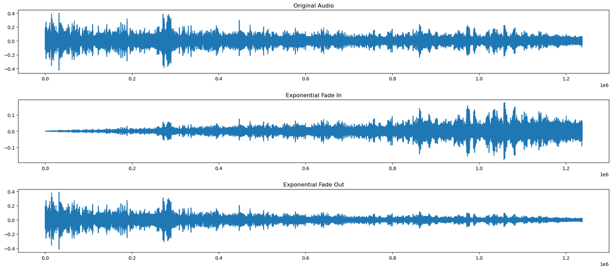

```python
# Plot untuk visualisasi
fig, ax = plt.subplots(3, 1, figsize=(18, 8))
# Plot audio original
ax[0].plot(y)
ax[0].set_title('Original Audio')
# Plot audio dengan fade in
ax[1].plot(audio_fade_in)
ax[1].set_title('Exponential Fade In')
# Plot audio dengan fade out
ax[2].plot(audio_fade_out)
ax[2].set_title('Exponential Fade Out')
plt.tight_layout()
plt.show()
```

Pada tahapan ini, akan menampilkan bentuk sinyal audio sebelum dan sesudah diterapkan efek fading eksponensial (baik fade in maupun fade out).

```python
# Save hasil audio di folder 'data'
sf.write('data/bird_faded_in.wav', audio_fade_in, sr)
sf.write('data/bird_faded_out.wav', audio_fade_out, sr)
```

Dengan cara ini, file audio hasil fading akan disimpan di dalam folder data.

3. Dengan menggunakan file audio yang anda rekam sendiri (suara anda), lakukanlah kompresi dan normalisasi hingga loudness LUFS mencapai kira-kira sekitar -14 LUFS. Berikan penjelasan langkah-langkah yang anda lakukan untuk menyelesaikan tugas ini.

```python
import soundfile as sf
import numpy as np
import os
import wave
import matplotlib.pyplot as plt
import librosa
import librosa.display
```

```python
percobaan3 = os.path.join(os.getcwd(), 'data', 'aboutme.wav')
```

```python
# Periksa jika file tidak ditemukan
if not os.path.exists(percobaan3):
    print(f"File {percobaan3} not found.")
    exit()
```

```python
# Membaca file WAV
with wave.open(percobaan3, 'r') as wav_file:
    frames_percobaan3 = wav_file.readframes(-1)
    sample_percobaan3 = np.frombuffer(frames_percobaan3, dtype='int16')
    fr_percobaan3 = wav_file.getframerate()

    # Mendapatkan informasi channel
    channel_percobaan3 = wav_file.getnchannels()
```

```python
# Tampilkan informasi file WAV
print(f"Isi dari sound_data: {sample_percobaan3}")
print(f"Panjang dari sound_data: {len(sample_percobaan3)}")
print(f"Sampling rate: {fr_percobaan3}")
print(f"Jumlah channel: {channel_percobaan3}")
```

```
Isi dari sound_data: [0 0 0 ... 0 0 0]
Panjang dari sound_data: 1082880
Sampling rate: 48000
Jumlah channel: 1
```

```python
# Membuat sumbu waktu
time_axis_original = np.linspace(0, len(sample_percobaan3) / fr_percobaan3, len(sample_percobaan3))
print(f"Panjang time axis : {len(time_axis_original)}")
```

```
Panjang time axis : 1082880
```

```python
# Plotting audio original
plt.figure(figsize=(18, 5))
plt.plot(time_axis_original, sample_percobaan3)
plt.title('Waveform Audio Original')
plt.xlabel('Waktu (detik)')
plt.show()
```

[output not shown]

```python
# Mencari nilai maksimal dari audio
nilai_maksimal = np.max(np.abs(sample_percobaan3))
print(f"Nilai maksimal dari audio: {nilai_maksimal}")

# Membuat threshold kompresi
thresholdkompresi = 0.4 * nilai_maksimal
print(f"Threshold kompresi: {thresholdkompresi}")
```

```
Nilai maksimal dari audio: 11899
Threshold kompresi: 4759.6
```

```python
# Melakukan kompresi
kompresipercobaan3 = sample_percobaan3.copy()
```

```python
# Mengganti nilai yang lebih kecil dari threshold dengan nilai threshold
mask = np.abs(kompresipercobaan3) > thresholdkompresi
```

```python
print(f"Jumlah nilai yang lebih besar dari threshold: {np.sum(mask)}")
```

```
Jumlah nilai yang lebih besar dari threshold: 13712
```

```python
rasiokompresi = 5

# Kompresi nilai yang lebih kecil dari threshold
kompresipercobaan3[mask] = kompresipercobaan3[mask] / rasiokompresi
kompresipercobaan3 = np.clip(kompresipercobaan3, -nilai_maksimal, nilai_maksimal)
```

```python
time_axis_kompresi = np.linspace(0, len(kompresipercobaan3) / fr_percobaan3, len(kompresipercobaan3))
```

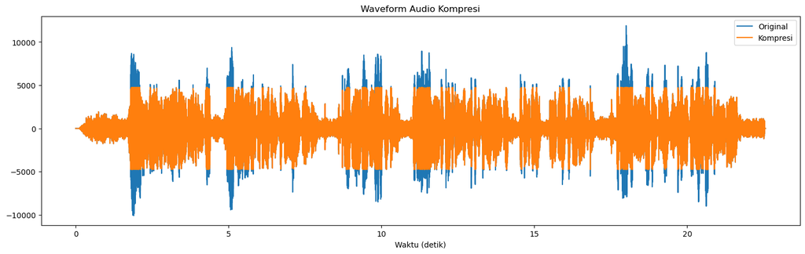

```python
plt.figure(figsize=(18, 5))
plt.plot(time_axis_original, sample_percobaan3, label='Original')
plt.plot(time_axis_kompresi, kompresipercobaan3, label='Kompresi')
plt.title('Waveform Audio Kompresi')
plt.xlabel('Waktu (detik)')
plt.tight_layout
plt.legend()
plt.show()
```

```python
# Menentukan a dan b
b = np.array([1.53512485958697, -2.69169618940638, 1.19839281085285])
a = np.array([1.0, -1.69065929318241, 0.73248077421585])
```

```python
# Membuat array kosong untuk menyimpan hasil filter
floatpercobaan3 = sample_percobaan3.astype(np.float32) / np.iinfo(np.int16).max
percobaan3difilter = np.zeros_like(floatpercobaan3)

# Melakukan filter
for i in range(len(floatpercobaan3)):
    if i < 2:
        percobaan3difilter[i] = floatpercobaan3[i]
    else:
        percobaan3difilter[i] = b[0] * floatpercobaan3[i] + b[1] * floatpercobaan3[i-1] + b[2] * floatpercobaan3[i-2] - a[1] * percobaan3difilter[i-1] - a[2] * percobaan3difilter[i-2]
```

```python
# Menghitung mean square
mean_square = np.mean(np.square(percobaan3difilter))
print(f"Mean square dari audio: {mean_square}")
```

```
Mean square dari audio: 0.002437644638121128
```

```python
# Periksa jika mean_square > 0
if mean_square > 0:
    lufs = -0.691 + 10 * np.log10(mean_square)
else:
    lufs = float('nan')  # output jika mean_square <= 0

print(f"LUFS: {lufs}")
```

```
LUFS: -26.821297183990477
```

Agar LUFS mendekati -14, maka bisa dikalikan dengan gain factor. Gain factor digunakan untuk menyesuaikan level loudness dari audio agar mencapai target loudness yang diinginkan. Rumus untuk menghitung gain factor adalah sebagai berikut:

Gain factor = 10 (Target LUFS - LUFS Sementara / 20)